# Load Data

```python
import pandas as pd

df_UserBehavior = pd.read_csv('https://storage.googleapis.com/datalynn-datasets/interview-challenge/technology/Salesforce_Personalization/UserBehavior.csv')
df_UserBehavior.head()
```

|  | UserID | ProductID | Timestamp | ActivityType | Price | Platform | Location | AdClick | SessionTime | PurchaseFreq |
| --- | --- | --- | --- | --- | --- | --- | --- | --- | --- | --- |
| 0 | 1 | 4 | 2023-01-01 00:00:00 | Browse | 32.814263 | Desktop | Location_B | 0 | 145 | 0 |
| 1 | 2 | 6 | 2023-01-01 00:01:00 | Browse | 194.871862 | Mobile | Location_C | 0 | 102 | 0 |
| 2 | 3 | 1 | 2023-01-01 00:02:00 | Purchase | 868.028095 | Mobile | Location_A | 1 | 254 | 1 |
| 3 | 4 | 10 | 2023-01-01 00:03:00 | Purchase | 202.227283 | Mobile | Location_C | 0 | 208 | 2 |
| 4 | 5 | 6 | 2023-01-01 00:04:00 | Purchase | 670.126894 | Mobile | Location_A | 1 | 166 | 2 |

```python
df = df_UserBehavior.copy()
```

## Question 1

**Data Manipulation & Cleaning**  
Given the `UserBehavior` table, there seems to be some irregularities with the `SessionTime`.

**Scenario**: Due to a recent UI update, some users reported glitches that might have led to inaccurate `SessionTime` recordings.

- Identify potential outliers in `SessionTime` and discuss how you'd manage them, particularly in sessions where an `AdClick` was recorded.

```python
import pandas as pd

# Calculate Q1, Q3 and IQR for SessionTime
Q1 = df['SessionTime'].quantile(0.25)
Q3 = df['SessionTime'].quantile(0.75)
IQR = Q3 - Q1

# Define bounds
lower_bound = Q1 - 1.5 * IQR
upper_bound = Q3 + 1.5 * IQR

# Identify potential outliers
outliers = df[(df['SessionTime'] < lower_bound) | (df['SessionTime'] > upper_bound)]

# Filter sessions where an AdClick was recorded
adclick_outliers = outliers[outliers['AdClick'] == True]

adclick_outliers.head()
```

|  | UserID | ProductID | Timestamp | ActivityType | Price | Platform | Location | AdClick | SessionTime | PurchaseFreq |
| --- | --- | --- | --- | --- | --- | --- | --- | --- | --- | --- |
| 58 | 59 | 8 | 2023-01-01 00:58:00 | Purchase | 41.970452 | Desktop | Location_A | 1 | 10000 | 3 |
| 62 | 63 | 83 | 2023-01-01 01:02:00 | Purchase | 407.063455 | Mobile | Location_B | 1 | 10000 | 1 |
| 79 | 80 | 20 | 2023-01-01 01:19:00 | Purchase | 796.059166 | Mobile | Location_B | 1 | 10000 | 1 |
| 137 | 138 | 6 | 2023-01-01 02:17:00 | Purchase | 819.070678 | Mobile | Location_B | 1 | 10000 | 2 |
| 143 | 144 | 9 | 2023-01-01 02:23:00 | Purchase | 942.863830 | Mobile | Location_B | 1 | 10000 | 1 |

Methods to handle the outliers

- Removal:
  - For clearly erroneous data like negative session times, removal is the best option.
  - For sessions with extremely high session times that appear to be system glitches, consider removing them to avoid skewing the analysis.
- Imputation:
  - If the outliers are not too frequent, consider replacing them with median values (median is resistant to outliers). However, this can potentially introduce bias.
- Separate Analysis:
  - Treat outliers separately. For instance, analyze user behavior for both "typical" sessions and "outlier" sessions separately to derive insights.

## Question 2

**Probability and Statistics**  
We want to explore the relationship between `SessionTime` and the frequency of purchases (`PurchaseFreq`).

**Scenario**: Stakeholders believe there's a positive correlation between these two variables.

- Using statistical analysis, test if longer session times lead to higher purchase frequencies.

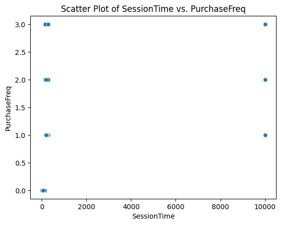

```
Pearson's correlation coefficient: 0.17
```

```python
import pandas as pd
import numpy as np
import matplotlib.pyplot as plt
import seaborn as sns

# Visual Inspection
sns.scatterplot(x='SessionTime', y='PurchaseFreq', data=df)
plt.title("Scatter Plot of SessionTime vs. PurchaseFreq")
plt.show()

# Correlation Coefficient
correlation_coefficient = df['SessionTime'].corr(df['PurchaseFreq'])
print(f"Pearson's correlation coefficient: {correlation_coefficient:.2f}")
```

From the scatter plot and Pearson's correlation coefficient, we can say that there is no strong positive correlation between these `Session_time` and `PurchaseFreq`.

## Question 3

**Machine Learning & Modeling**  
We aim to better understand and predict a user's likelihood to click on an ad (`AdClick`).

**Scenario**: Marketing teams suggest that `SessionTime` and `Platform` are good predictors for ad clicks.

- Using the relevant features from `UserBehavior`, build a model to predict `AdClick`. Clearly state the target variable and its type.
- Target variable: `AdClick`. Type: Binary

```python
import pandas as pd
from sklearn.model_selection import train_test_split
from sklearn.linear_model import LogisticRegression
from sklearn.metrics import accuracy_score, classification_report, roc_auc_score

df2 = df.copy()
# One-Hot Encoding of 'Platform' column
df_encoded = pd.get_dummies(df2, columns=['Platform'])

# Features and target variable
X = df_encoded.drop(columns=['AdClick'])  # Drop the target column for features
X = X[['SessionTime'] + [col for col in df_encoded if col.startswith('Platform_')]]  # Select SessionTime and Platform encoded columns
y = df_encoded['AdClick']

X_train, X_test, y_train, y_test = train_test_split(X, y, test_size=0.3, random_state=42)

# Logistic Regression Model
clf = LogisticRegression(max_iter=1000)  # Increase max_iter if convergence issues arise
clf.fit(X_train, y_train)

# Predictions
y_pred = clf.predict(X_test)
y_pred_prob = clf.predict_proba(X_test)[:,1]

# Evaluation
accuracy = accuracy_score(y_test, y_pred)
roc_auc = roc_auc_score(y_test, y_pred_prob)
print(f"Accuracy: {accuracy:.2f}")
print(f"ROC-AUC Score: {roc_auc:.2f}")
print(classification_report(y_test, y_pred))
```

```
Accuracy: 0.81
ROC-AUC Score: 0.60
              precision    recall  f1-score   support

           0       0.81      0.99      0.89      2391
           1       0.75      0.07      0.12       609

    accuracy                           0.81      3000
   macro avg       0.78      0.53      0.51      3000
weighted avg       0.80      0.81      0.73      3000
```

## Question 4

**Product Design & Analytics**  
To evaluate the impact of our tailored product recommendations:

**Scenario**: Preliminary feedback suggests users from specific `Locations` interact differently with product recommendations after an `AdClick`.

- Analyze the data to see if there's a significant variation in `ActivityType` post `AdClick` across different `Locations`.

```python
from scipy.stats import chi2_contingency

# Filter the dataset for records with AdClick = 1
ad_clicked_df = df_UserBehavior[df_UserBehavior['AdClick'] == 1]

# Create a contingency table
contingency_table = pd.crosstab(ad_clicked_df['Location'], ad_clicked_df['ActivityType'])

print("Contingency Table:")
print(contingency_table)

# Chi-square test
chi2, p_value, _, _ = chi2_contingency(contingency_table)

print("\nChi-Square Value =", chi2)
print("P-Value =", p_value)

if p_value < 0.05:
    print("There's a significant variation in ActivityType post AdClick across different Locations.")
else:
    print("There's no significant variation in ActivityType post AdClick across different Locations.")
```

```
Contingency Table:
ActivityType  Browse  Purchase
Location
Location_A       447       725
Location_B       237       385
Location_C        68       136

Chi-Square Value = 1.7935840818145987
P-Value = 0.4078760128206945
There's no significant variation in ActivityType post AdClick across different Locations.
```